# Prior-Data Conflict Diagnostics

Ndoh Penn

2026-05-22

# Why Conflict Diagnostics Matter

Before updating a prior with trial data it is essential to check whether the two are compatible. Substantial prior-data conflict indicates one of three things: the prior was mis-specified, the data are anomalous, or the model is wrong. Regulators increasingly require evidence that conflict was assessed and addressed.

**bayprior** provides four complementary univariate diagnostics and one multivariate diagnostic, following Box (1980) and related work. The conflict module supports **four data types**: binary, continuous, Poisson/count, and survival.

# Supported Data Types

| Data type | `type =` argument | Conjugate update | Typical endpoint |
| --- | --- | --- | --- |
| Binary | `"binary"` | Beta–Binomial | Response rate, ORR |
| Continuous | `"continuous"` | Normal–Normal | Mean difference, HbA1c |
| Poisson / count | `"poisson"` | Gamma–Poisson | Adverse event rate |
| Survival | `"survival"` | Gamma–Exponential | Hazard rate, OS, PFS |

# Univariate Conflict: `prior_conflict()`

## Binary Data

```r
prior <- elicit_beta(
  mean = 0.30, sd = 0.10, method = "moments",
  label = "Response rate"
)
```

```r
# No-conflict: data consistent with prior
cd_none <- prior_conflict(
  prior        = prior,
  data_summary = list(type = "binary", x = 13, n = 40),
  alpha        = 0.05
)
print(cd_none)
```

[output not shown]

```r
# Mild conflict
cd_mild <- prior_conflict(
  prior        = prior,
  data_summary = list(type = "binary", x = 20, n = 40)
)
print(cd_mild)
```

[output not shown]

```r
# Severe conflict
cd_severe <- prior_conflict(
  prior        = prior,
  data_summary = list(type = "binary", x = 35, n = 40)
)
print(cd_severe)
```

[output not shown]

# The Four Diagnostics Explained

## 1. Box’s Prior Predictive P-value

$$p_{\text{Box}} =
2\Phi\!\left(-\left|\frac{\hat\theta - \mu_\pi}
{\sqrt{\sigma_\pi^2 + \text{SE}^2}}\right|\right)$$

**Interpretation:** $p < 0.05$ flags conflict at the 5% level.

## 2. Surprise Index

$$S = \left|\frac{\hat\theta - \mu_\pi}
{\sqrt{\sigma_\pi^2 + \text{SE}^2}}\right|$$

**Interpretation:** $S > 2$ moderate; $S > 3$ high surprise.

## 3. KL Divergence

$$\text{KL}(P \| Q) =
\log\frac{\sigma_Q}{\sigma_P}
+ \frac{\sigma_P^2 + (\mu_P - \mu_Q)^2}{2\sigma_Q^2} -
\frac12$$

**Interpretation:** $> 1$ indicates large information distance.

## 4. Bhattacharyya Overlap Coefficient

$$\text{BC} = \exp\!\left(
-\frac{(\mu_P - \mu_Q)^2}{4(\sigma_P^2 + \sigma_Q^2)}\right)
\cdot \left(\frac{2\sigma_P\sigma_Q}
{\sigma_P^2 + \sigma_Q^2}\right)^{1/2}$$

**Interpretation:** 1 = identical distributions; 0 = no overlap.

## Threshold Summary

| Diagnostic | No conflict | Mild conflict | Severe conflict |
| --- | --- | --- | --- |
| Box p-value | >= 0.05 | 0.01-0.05 | < 0.01 |
| Surprise index | < 2 | 2-3 | > 3 |
| KL divergence | < 0.5 | 0.5-1 | > 1 |
| Bhattacharyya overlap | > 0.6 | 0.3-0.6 | < 0.3 |

# Prior-Likelihood-Posterior Overlay

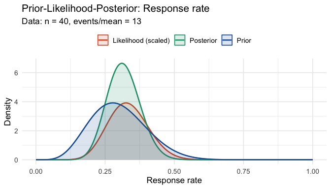

```r
plot_prior_likelihood(
  prior,
  data_summary   = list(type = "binary", x = 13, n = 40),
  show_posterior = TRUE
)
```

*No conflict: prior and likelihood overlap substantially.*

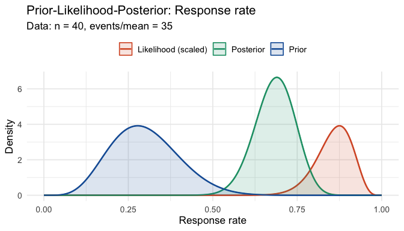

```r
plot_prior_likelihood(
  prior,
  data_summary   = list(type = "binary", x = 35, n = 40),
  show_posterior = TRUE
)
```

*Severe conflict: prior (blue) and likelihood (orange) widely separated.*

# Continuous Endpoint Conflict

```r
prior_norm <- elicit_normal(
  mean = 0.0, sd = 0.3, method = "moments",
  label = "Log odds ratio"
)

# No conflict: observed log OR consistent with prior
prior_conflict(
  prior_norm,
  data_summary = list(type = "continuous", x = 0.15, sd = 0.20, n = 80)
)
```

[output not shown]

# Poisson / Count Data Conflict

Poisson/count data arises for endpoints such as adverse event rates, where the observed data consists of a count of events over an exposure period (person-time). The conjugate update uses a **Gamma-Poisson** model:

$$\text{Prior: Gamma}(\alpha, \beta)
\quad\Rightarrow\quad
\text{Posterior: Gamma}(\alpha + x,\; \beta + n)$$

where $x$ = observed events and $n$ = total person-time.

```r
# Gamma prior on adverse event rate
# Expert believes the AE rate is ~0.15 events per person-year (SD 0.06)
prior_ae <- elicit_gamma(
  mean      = 0.15,
  sd        = 0.06,
  method    = "moments",
  label     = "Adverse event rate (per person-year)",
  expert_id = "Safety Expert"
)
print(prior_ae)
```

[output not shown]

```r
# Observed: 12 AEs over 100 person-years => rate 0.12 — consistent with prior
cd_pois_none <- prior_conflict(
  prior        = prior_ae,
  data_summary = list(type = "poisson", x = 12, n = 100),
  alpha        = 0.05
)
print(cd_pois_none)
```

[output not shown]

```r
# Observed: 40 AEs over 100 person-years => rate 0.40 — much higher than prior
cd_pois_conf <- prior_conflict(
  prior        = prior_ae,
  data_summary = list(type = "poisson", x = 40, n = 100)
)
print(cd_pois_conf)
```

[output not shown]

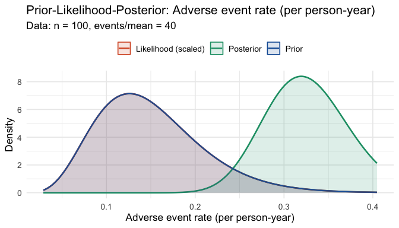

```r
plot_prior_likelihood(
  prior_ae,
  data_summary   = list(type = "poisson", x = 40, n = 100),
  show_posterior = TRUE
)
```

# Survival / Time-to-Event Data Conflict

Survival data conflict arises for endpoints like OS and PFS hazard rates. The observed data consists of event counts over a total follow-up time (person-months). The conjugate update uses a **Gamma-Exponential** model:

$$\text{Prior: Gamma}(\alpha, \beta)
\quad\Rightarrow\quad
\text{Posterior: Gamma}(\alpha + d,\; \beta + T)$$

where $d$ = observed events and $T$ = total follow-up time.

An Exponential prior (constant hazard) is equivalent to $\text{Gamma}(1, \lambda)$.

```r
# Exponential prior on hazard rate
# Expert believes median OS ≈ 20 months => hazard ≈ 0.05
prior_hz <- elicit_exponential(
  mean      = 0.05,
  method    = "moments",
  label     = "OS hazard rate",
  expert_id = "Clinical Expert"
)
print(prior_hz)
```

[output not shown]

```r
# Observed: 20 deaths over 400 person-months => hazard 0.05 — consistent
cd_surv_none <- prior_conflict(
  prior        = prior_hz,
  data_summary = list(type = "survival", x = 20, n = 400),
  alpha        = 0.05
)
print(cd_surv_none)
```

[output not shown]

```r
# Observed: 60 deaths over 400 person-months => hazard 0.15 — much higher
cd_surv_conf <- prior_conflict(
  prior        = prior_hz,
  data_summary = list(type = "survival", x = 60, n = 400)
)
print(cd_surv_conf)
```

[output not shown]

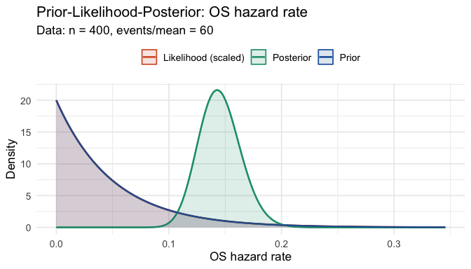

```r
plot_prior_likelihood(
  prior_hz,
  data_summary   = list(type = "survival", x = 60, n = 400),
  show_posterior = TRUE
)
```

Also works with a Gamma prior on the hazard rate:

```r
prior_hz_gamma <- elicit_gamma(
  mean = 0.05, sd = 0.02, method = "moments",
  label = "OS hazard rate (Gamma prior)"
)
prior_conflict(
  prior_hz_gamma,
  data_summary = list(type = "survival", x = 20, n = 400)
)
```

[output not shown]

# Compatibility Validation

bayprior warns when the prior family is atypical for the chosen data type, helping users avoid inadvertent misspecification:

```r
# Warning: Beta prior with Poisson data is unusual
prior_beta <- elicit_beta(mean = 0.15, sd = 0.06, method = "moments",
                           label = "Rate")
# The app shows a warning notification; the function still runs with
# a Normal approximation
cd_warn <- prior_conflict(
  prior_beta,
  data_summary = list(type = "poisson", x = 15, n = 100)
)
```

# Mixture Prior Conflict

All diagnostics work transparently with mixture priors via a Normal approximation from the mixture’s `fit_summary`:

```r
e1 <- elicit_beta(mean = 0.25, sd = 0.08, method = "moments",
                  expert_id = "E1", label = "ORR")
e2 <- elicit_beta(mean = 0.40, sd = 0.12, method = "moments",
                  expert_id = "E2", label = "ORR")
mix <- aggregate_experts(list(E1 = e1, E2 = e2), weights = c(0.5, 0.5))

prior_conflict(mix, list(type = "binary", x = 18, n = 40))
```

[output not shown]

# Multivariate Conflict: `conflict_mahalanobis()`

For trials with co-primary endpoints, the Mahalanobis distance provides an omnibus multivariate conflict test:

```r
conflict_mahalanobis(
  prior_means = c(0.35, 0.60),
  prior_cov   = matrix(c(0.010, 0.003, 0.003, 0.015), 2, 2),
  obs_means   = c(0.55, 0.58),
  obs_cov     = matrix(c(0.008, 0.002, 0.002, 0.010), 2, 2) / 50,
  labels      = c("Response rate", "OS rate"),
  alpha       = 0.05
)
```

```
##
## Marginal z-scores per parameter:
## Response rate       OS rate
##         1.984        -0.162
```

# Conflict Severity Classification

| Severity | Recommended action |
| --- | --- |
| **None** | Proceed — prior is consistent with data |
| **Mild** | Consider reporting both prior-weighted and likelihood-only estimates |
| **Severe** | Revise prior or use a robust/power prior; report sensitivity |

# References

- Box, G. E. P. (1980). Sampling and Bayes’ inference in scientific modelling and robustness. *JRSS-A*, 143, 383–430.
- Bhattacharyya, A. (1943). On a measure of divergence between two statistical populations. *Bulletin of the Calcutta Mathematical Society*, 35, 99–109.